# FISH 627: Homework 3

Laura Stichert

Due by end of Thursday, October 22, 2015

**Note: my text answers are noted in green.**

**Total: 10 points**  
Out of fairness to others (and to me) I cannot accept late homework. I will subtract 0.5 points per day after the due date and will not accept homework that is more than a week late! If you have valid reasons such as field work, conferences, etc. that prevent you from turning in a homework on time, talk to me beforehand!

# Fitting a LOWESS model and plotting results:

For this problem we will estimate average ozone values at different levels of wind and temperature (as well as different levels of solar radiation) and plot the resulting estimates as a smooth surface.

**a.** (1 pt.) Attach the *lattice* library and explore the ozone data in data frame “environmental”. For simplicity, you may also want to attach the environmental data frame, but make sure you enderstand what happens when you do!

```r
library(lattice)
attach(environmental) # attach can induce some issues so we will detach asap
enviro <- environmental
detach(environmental)
str(enviro)
```

```
## 'data.frame':    111 obs. of  4 variables:
##  $ ozone      : num  41 36 12 18 23 19 8 16 11 14 ...
##  $ radiation  : num  190 118 149 313 299 99 19 256 290 274 ...
##  $ temperature: num  67 72 74 62 65 59 61 69 66 68 ...
##  $ wind       : num  7.4 8 12.6 11.5 8.6 13.8 20.1 9.7 9.2 10.9 ...
```

Plot a histogram of ozone using *‘hist’*. Compare a histogram of these “raw” ozone values to one that uses 3<sup>rd</sup> root transformed values (ozone^(1/3)). Describe the difference and explain why we would want to transform the ozone variable if used as dependent variable in a typical regression (this requires some familiarity with standard regression assumptions).

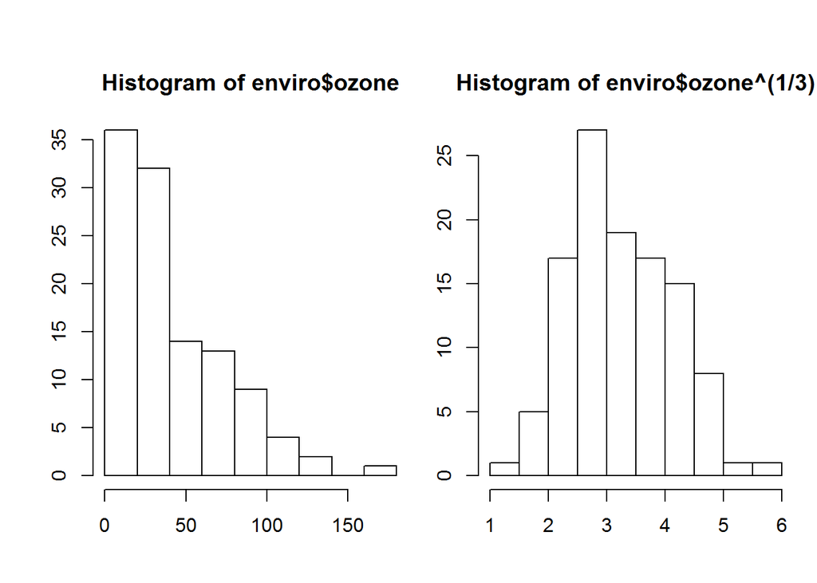

```r
par(mfrow=c(1,2), mar=c(2,2,3,1), omi=c(0.4,0.4,0.4,0))
hist(enviro$ozone)
hist(enviro$ozone^(1/3))
```

**The raw data is right-skewed and the third root transformed data is more normally distributed. We want to transform the dependent variable to makeit more normally distributed so we can make inferences from model output and create confidence intervals.**

**b.** (0.5 pt.) Fit a LOWESS model of (transformed) ozone levels on wind and temperature using the ‘loess’ function, similar to the model for GAK 1 temperatures that we fit in Module 8:

```r
ozo1 <- loess((ozone^(1/3)) ~ temperature + wind, data=enviro, span = 1, degree = 2)
```

Use the suggested setting and insert the appropriate *formula*.

**c.** (1 pt.) The LOWESS fit does not have regression coefficients like a linear regression model to compute predicted values, but you can extract the fitted values and residuals from the fitted model object (`ozo1`) using functions `fitted` and `resid`. Plot the observed values (on the transformed scale!!) against the fitted values. Add a 1:1 line to the plot (intercept 0, slope 1) that would denote a perfect fit (i.e. a 1:1 correspondence):  
`abline(0,1)`

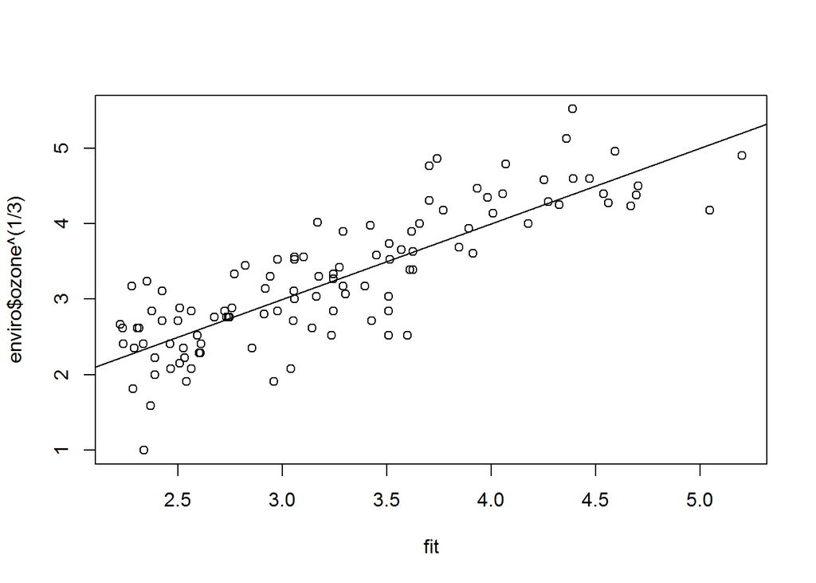

```r
fit<-fitted(ozo1)
plot(enviro$ozone^(1/3)~fit)
abline(0,1)
```

**d.** (1 pt.) The LOWESS model is similar to any linear regression in that it finds fitted values by minimizing the sum of squared differences between the observations and the fitted regression line or (in this case) the fitted 2-dimensional surface (as in “least-squares” regression, although LOWESS differs in that it uses a modified least-squares criterion). The model fit can be evaluated by examining the residual variability, which is described by the spread of the observed values around the fitted values and is typically quantified by the ‘residual standard error’.

You can view the residual standard error in the summary output using:  
`summary(ozo1)`

`str(ozo1)`

```r
summary(ozo1)
```

```
## Call:
## loess(formula = (ozone^(1/3)) ~ temperature + wind, data = enviro,
##     span = 1, degree = 2)
##
## Number of Observations: 111
## Equivalent Number of Parameters: 6.83
## Residual Standard Error: 0.501
## Trace of smoother matrix: 7.63
##
## Control settings:
##   normalize:  TRUE
##   span       :  1
##   degree   :  2
##   family   :  gaussian
##   surface  :  interpolate      cell = 0.2
```

```r
# Residual Standard Error: 0.501

p <- summary(ozo1)$enp
n <- summary(ozo1)$n
resid.sq <- (resid(ozo1)^2)
RSE <- sqrt(sum(resid.sq)/(n-p))
RSE
```

```
## [1] 0.4971813
```

For comparison, compute the standard error directly from the residuals. The residual standard error can be estimated as:

$\hat{\sigma}_{\varepsilon}^2=\sqrt{\sum\limits_{i=1}^n\sigma_{i}^2\Big/(n-p)}$

All the information you need is either in the `summary` output (n is the number of observations and p is the equivalent number of parameters) or can be extracted from the fitted object (i.e. `resid(ozo1)` returns the vector of residuals or e). You can use vectorized arithmetic, that is you can square the entire residual vector e and then sum over the elements ei using`'sum`. There is no need for looping (!!), and the above formula can be written as a single short expression using `sqrt`, `sum`, and basic arithmetic operators. You can take the values for *n* and *p* from ‘summary(ozo1)’ and simply type them into your expression to compute the standard error or you can extract n and p from the summary object and then use them in your expression:  
`p <- ozo1$enp`  
`n <- ozo1$n`

Use `str(ozo1)` to examine all available elements.  
(Note that the computed value for the standard error of the residuals differs somewhat from the value returned in the summary output due to slight differences in the way they are calculated).

**e.** (0.5 pt.) Remember that any regression model “decomposes” the data into predicted values (the fitted values you extracted earliler) plus the residual variability (the residuals you extracted earlier), that is: $y = \hat{y} + \hat{\varepsilon}$ where $y$ is the data vector, $\hat{y}$ is a vector of fitted values, and $\hat{\varepsilon}$ is a vector of residuals.

Verify that the sum of the fitted values and the residuals is equal to the observed ozone values (e.g. by plotting (fitted values + residual values) against (observed values) or by computing the differences, which should all be 0).

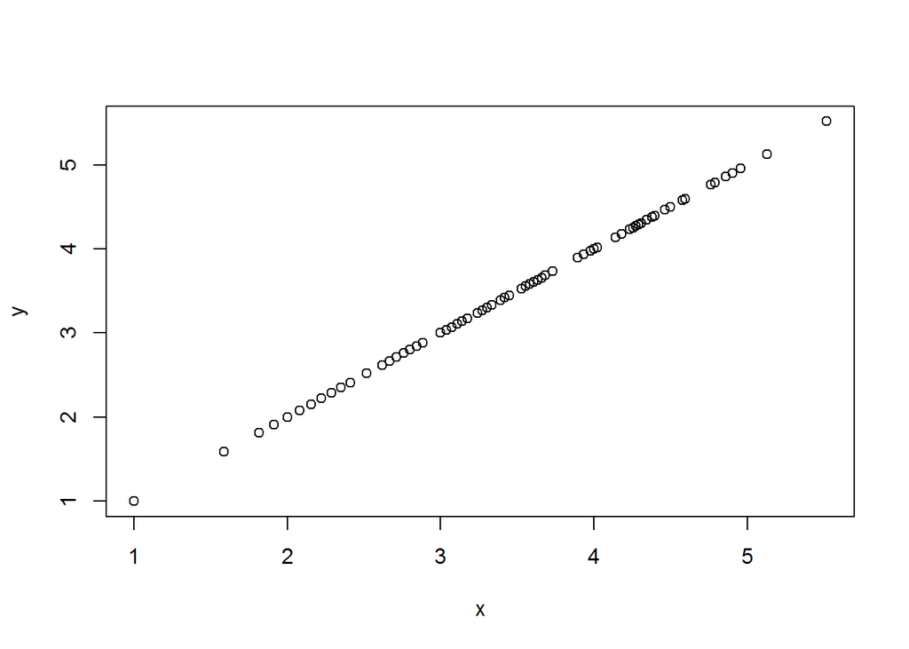

```r
x <- enviro$ozone^(1/3)
y <- ozo1$fitted+ozo1$residuals
plot(x,y)
```

```r
diff.ozo <- sum(x-y)
diff.ozo
```

```
## [1] 0
```

**f.** (1.5 pt.) Examine the fit of the model by doing some basic residual diagnostics / plots. Split the graphics window into 2 rows and 2 columns to examine all plots at once: `par(mfrow=c(2,2))`  
Create the following set of plots, which should be part of model checking whenever you fit a statistical model:

1. Plot residuals (on y-axis) against fitted values, add a horizontal line at 0 (`abline(h=0)`)
2. Plot residuals against wind and add line at 0
3. Plot residuals against temperature and add line at 0
4. Create a `qqplot` that compares the quantiles of the residual distribution against the corresponding quantiles of a normal distribution. If residuals are normally distributed, they should roughly fall on a straight line:  
   `qqnorm(resid(ozo1))`  
   `qqline(resid(ozo1))`

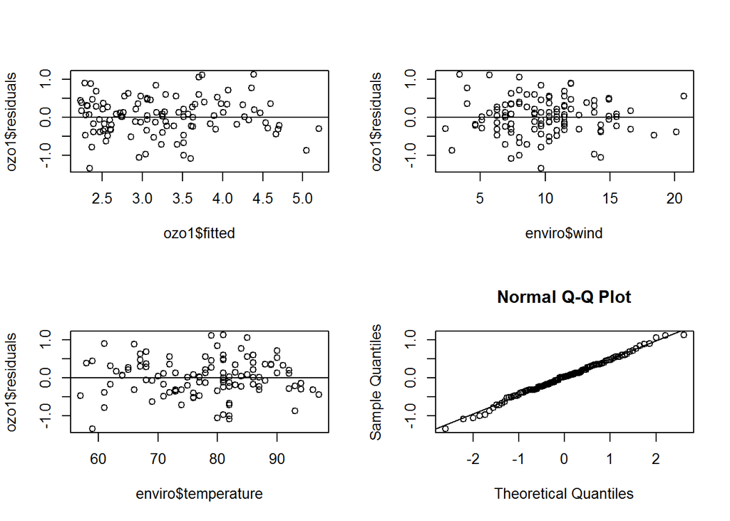

```r
par(mfrow=c(2,2))
plot(ozo1$fitted,ozo1$residuals)
abline(h=0)

plot(enviro$wind, ozo1$residuals)
abline(h=0)

plot(enviro$temperature, ozo1$residuals)
abline(h=0)

qqnorm(resid(ozo1))
qqline(resid(ozo1))
```

Briefly discuss whether the regression assumptions are met: There should be no obvious patterns in the residuals (i.e. they should be randomly distributed around the zero line), no heteroscedasticity (i.e. variability should be roughly constant across different fitted values and different values of the covariates), and they should be approximately normally distributed.

**It appears the regression assumptions are met as there are no obvious patterns in the residuals, no heteroscedasticity is apparent, and residuals appear approximately normally distributed.**

**g.** (1.5 pt.) Next, we set up a grid to compute predicted values on a regularly spaced grid for the purpose of plotting the predicted model surface (which provides an estimate of how ozone levels vary with wind speed and temperature):

- Use `seq` to create a regularly spaced sequence of numbers from the minimum wind measurement to the maximum and from the minimum temperature to the maximum. Use about 50 equally spaced values (i.e. `length.out=50`)  
  `wnd <- seq(min(enviro$wind), max(enviro$wind), length=50)`  
  `temp <- seq(..., ..., ...)`
- Create a matrix that contains a combination of each value in ‘wnd’ and each value in `temp`: `grd <- expand.grid(list(wind=wnd, temperature = temp))`  
  Examine `grd` to understand its structure!!
- Compute predicted values: Use the resulting matrix (`grd`) to compute predicted values and then to plot them. Note that the names of the variables in `grd` MUST match the names of the variables that we used in fitting the model! You can then use the “new” wind and temperature values to compute the predicted values at each combination of wind and temperature in `grd`:  
  `ozo1.fit <- predict(ozo1, newdata = grd)`  
  Examine the structure of the resulting matrix and compare its dimensions to the length of  
  `wnd` and `temp`.
- Following the example in Module 8, create an image plot of the fitted ozone values (on transformed scale) against wind and temperature:  
  `image(x=,yu=, z=, ...)` Add appropriate axis labels & title.  
  Use `col=terrain.colors(50)`
- Use the `contour` function to add contours to the image plot. `contour` takes the same x,y,z values as `image`, but be sure to set `add=T` to add contours to the existing plot (otherwise you get a new plot with contours only).
- Finally, use `points` to show where the actual measurements were taken as we did in Module 9.

Comment on the ability of the model to estimate ozone levels at a wind speed of 20mph when temperatures are in the 80s or 90s!

```r
wnd <- seq(min(enviro$wind), max(enviro$wind), length=50)
temp <- seq(min(enviro$temperature), max(enviro$temperature), length=50)
grd <- expand.grid(list(wind=wnd, temperature = temp))
str(grd)
```

```
## 'data.frame':    2500 obs. of  2 variables:
##  $ wind       : num  2.3 2.68 3.05 3.43 3.8 ...
##  $ temperature: num  57 57 57 57 57 57 57 57 57 57 ...
##  - attr(*, "out.attrs")=List of 2
##   ..$ dim     : Named num  50 50
##   .. ..- attr(*, "names")= chr  "wind" "temperature"
##   ..$ dimnames:List of 2
##   .. ..$ wind       : chr  "wind= 2.300000" "wind= 2.675510" "wind= 3.051020" "wind= 3.426531" ...
##   .. ..$ temperature: chr  "temperature=57.00000" "temperature=57.81633" "temperature=58.63265" "temperature=59.44898" ...
```

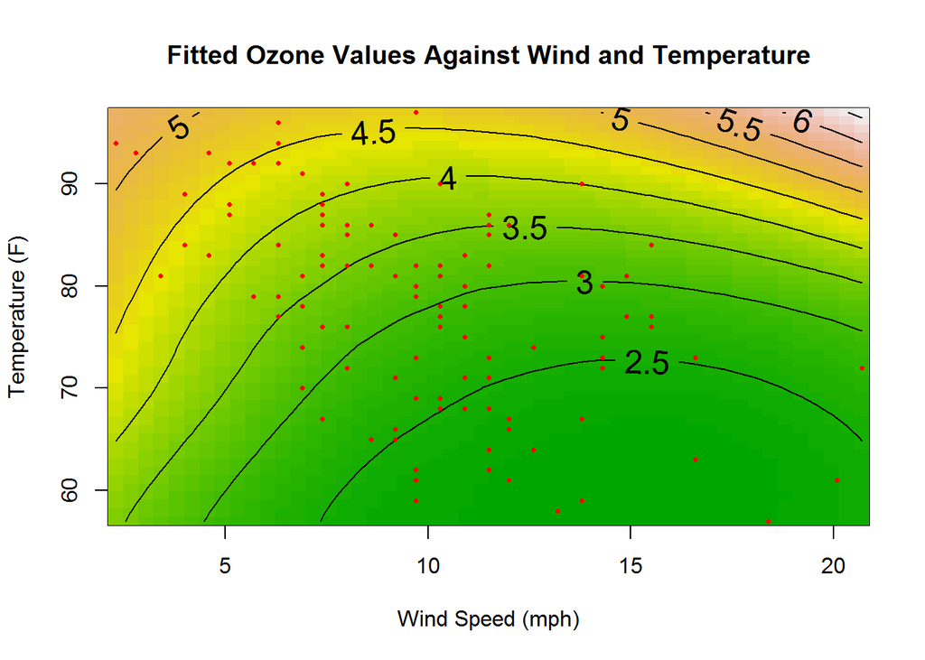

```r
ozo1.fit <- predict(ozo1, grd)

par(mfrow=c(1,1))
image(x=wnd, y=temp, z=ozo1.fit, xlab="Wind Speed (mph)", ylab="Temperature (F)",
main="Fitted Ozone Values Against Wind and Temperature", col=terrain.colors(50))
contour(x=wnd, y=temp, z=ozo1.fit, add=T, labcex=1.5)
points(environmental$wind, environmental$temperature, pch=16, cex=0.5, col=2)
```

**The model predicts values across all combinations of temperature and wind speed, even for cominations where there are not underlying observations. However, it is difficult to draw conclusions based on predictions where there aren’t observations (such as for ozone levels at a wind speed of 20 mph when temperatures are in the 80s or 90s).**

**h.** (0.5 pt.) Compare your image plot to an alternative solution that uses the lattice function ‘contourplot’, which automatically adds a legend. It works somewhat differently and we need to add the fitted values to the ‘grd’ matrix in order to use it:

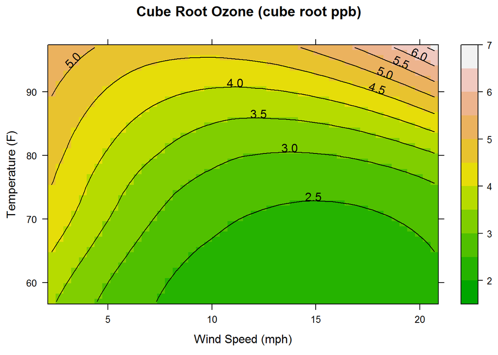

```r
par(mfrow=c(1,1))
grd[, "fit"] <- c(predict(ozo1, grd))
contourplot(fit ~ wind + temperature, data = grd,
 cuts = 10, region = TRUE,
 xlab = "Wind Speed (mph)",
 ylab = "Temperature (F)",
 main = "Cube Root Ozone (cube root ppb)",
 col.regions = terrain.colors(50))
```

**i.** (1.5 pt.) Extend the model with two independent variables `ozo1` to include an additional covariate - solar radiation - which may also have an effect on ozone levels. The model fits a “hyper-surface” to the data in 3 dimensions. You can think of it as a multiple regression of ozone on three independent variables with all possible interactions. (where the “interactions” are a bit more flexible in a LOWESS model than in a linear model). The model essentially allows for a different ozone response to temperature and wind conditions at different levels of solar radiation:

```r
ozo2 = loess((ozone^(1/3)) ~ wind + temperature + radiation, data=enviro, span=1, degree=2)
summary(ozo2)
```

```
## Call:
## loess(formula = (ozone^(1/3)) ~ wind + temperature + radiation,
##     data = enviro, span = 1, degree = 2)
##
## Number of Observations: 111
## Equivalent Number of Parameters: 11.32
## Residual Standard Error: 0.4538
## Trace of smoother matrix: 13.12
##
## Control settings:
##   normalize:  TRUE
##   span       :  1
##   degree   :  2
##   family   :  gaussian
##   surface  :  interpolate      cell = 0.2
```

```r
# Compare the two models with an F test:
anova(ozo1, ozo2)
```

```
## Model 1: loess(formula = (ozone^(1/3)) ~ temperature + wind, data = enviro, span = 1, degree = 2)
## Model 2: loess(formula = (ozone^(1/3)) ~ wind + temperature + radiation, data = enviro, span = 1, degree = 2)
##
## Analysis of Variance:   denominator df 98.06
##
##        ENP    RSS F-value    Pr(>F)
## [1,]  6.83 25.749
## [2,] 11.32 19.790  4.4603 0.0006947 ***
## ---
## Signif. codes:  0 '***' 0.001 '**' 0.01 '*' 0.05 '.' 0.1 ' ' 1
```

Use an approximate F-test to compare the model fits:  
`anova(ozo1, ozo2)`

This is equivalent to comparing two nested linear models. From regression you should remember that nested models can be compared by evaluating the reduction in residual sum of squares (RSS) that results from fitting a more complex model (e.g. by adding another covariate in the model). The ‘anova’ function is used to carry out this F-test (which is only approximate in this case because this is not a linear model).

How much did the residual sum of squares decrease in the more complex model (ozo2) compared to the simpler model (ozo1)? How many extra “equivalent parameters” were needed to achieve that reduction?

**The residual sum of squares decreased by 5.959 in the more complex model (ozo2) compared to the simpler model (ozo1); however, this took 4.49 additional “equivalent parameters” to achieve that reduction.**

**From the anova comparison of models, the probability that we would get an F value as large as the observed one under the “null hypothesis” is 0.0006947. Therefore, we can conclude that the more complex model, ozo2, is the better model.**

From the output above, what is the probability that we would get an F value as large as the observed one under the “null hypothesis” (which states that the simpler model is the “true” model)? What can you conclude about the models (i.e. which one appears to be the better model)?

**j.** (1 pt.) pt) Lastly, set up a 3-D grid with 4 different levels of radiation, compute predicted values, and plot the results as before, but with a different fitted surface at each of 4 radiation levels: `rad <- seq(min(radiation), max(radiation), length = 4)`  
`grd <- expand.grid(list(wind=wnd, temperature = temp, radiation=rad))`  
Examine `grd` to understand its structure!

Compute predicted values and add them to the matrix:  
`pred <- predict(ozo2, grd)`  
Examine `pred` (using `str`, `dim`, etc) to understand its structure! It returns an array of predicted values from our regression model with one predicted value at each combination of wind speed, temperature, and radiation level!

The next line of code converts the array to a long vector and appends it to the `grd` matrix:  
`grd[, "fit"] <- pred`

Examine `grd` again to understand what you just did!  
Create a plot of the fitted values at different combinations of wind and temperature and at four different levels of radiation:

```r
rad = seq(min(enviro$radiation), max(enviro$radiation), length = 4)
grd2 = expand.grid(wind=wnd, temperature = temp, radiation=rad, KEEP.OUT.ATTRS = FALSE)
head(grd2)
```

```
##       wind temperature radiation
## 1 2.300000          57         7
## 2 2.675510          57         7
## 3 3.051020          57         7
## 4 3.426531          57         7
## 5 3.802041          57         7
## 6 4.177551          57         7
```

```r
pred = predict(ozo2, grd2)
head(pred)
```

```
##        1        2        3        4        5        6
## 2.968905 2.890251 2.814028 2.740380 2.669447 2.601372
```

```r
dim(pred)
```

[output not shown]

```r
mode(pred)
```

```
## [1] "numeric"
```

```r
grd2[, "fit"] = as.vector(pred)
head(grd2)
```

```
##       wind temperature radiation      fit
## 1 2.300000          57         7 2.968905
## 2 2.675510          57         7 2.890251
## 3 3.051020          57         7 2.814028
## 4 3.426531          57         7 2.740380
## 5 3.802041          57         7 2.669447
## 6 4.177551          57         7 2.601372
```

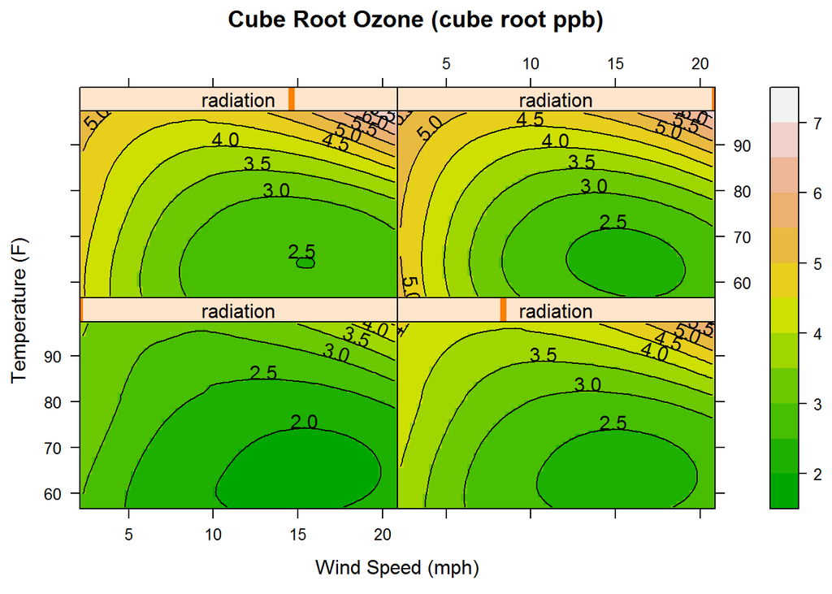

```r
contourplot(fit ~ wind * temperature | radiation, data = grd2,
            cuts = 10, region = TRUE,
            xlab = "Wind Speed (mph)",
            ylab = "Temperature (F)",
            main = "Cube Root Ozone (cube root ppb)",
            col.regions = terrain.colors(50))
```

In the resulting figure, the solar radiation level increases from the lower left panel to the upper right panel as indicated by the orange vertical bar in the strips at the top of each panel.

How do the estimated ozone levels differ at different levels of radiation?

**Contrary to what I would expect, as radiation levels increase, so do ozone levels, especially at high temperatures or low wind speeds.**

**Code used to generate this document**  
https://github.com/ben-williams/ReproResearch/blob/master/hwk3.Rmd